# Time Series HW 7

Anusha Bhat

2025-03-05

```r
library(TSA)
library(forecast)
library(dplyr)
library(lubridate)
library(corrplot)
library(fracdiff)
library(fGarch)
library(tseries)
library(MASS)
library(bsts)
```

```r
# load data
classif = read.csv("Contracts_Classification.csv")
vol = read.csv("Contracts_Volume.csv")
```

```r
# need to join the two dfs on Commodity so rename column in classif df
colnames(classif)[1] = "Commodity.Indicator"
```

# Task A

Program that: - makes Floor Vol col (Total - Electronic) - sort out which rows are for CME, IMM, and IOM - aggregate the data for each commodity indicator for each month - end table should look like: Date Elec.Vol Tot.Vol Flo.Vol

```r
# Join the two dfs first:
df = left_join(vol, classif, by = "Commodity.Indicator")

# note: should have more rows since some commodities can be sold by more than
# one group
```

```r
make_agg_tab = function(df){
  # create final table
  df =  df %>%
    # make Date col date type not chr
    mutate(Date = as.Date(Date, format = "%m/%d/%Y")) %>%
    # aggregate monthly data
  group_by(Date) %>%
  summarize(
    Total.Volume = sum(Total.Volume, na.rm = TRUE),
    Electronic.Volume = sum(Electronic.Volume, na.rm = TRUE),
    Floor.Volume = sum(Floor.Volume, na.rm = TRUE)
  ) %>%
    # sort by date
    arrange(Date)

  return(df)
}
```

```r
make_dfs = function(df)
{
  # Make Floor Vol Column
  # Need to format Elec Vol correctly first
  df$Electronic.Volume = as.numeric(gsub(",", "", df$Electronic.Volume))
  df$Floor.Volume = df$Total.Volume - df$Electronic.Volume

  # Sort into the 3 commodity groups
  cme_df = df # can trade everything
  imm_df = filter(df, Division == "IMM")
  iom_df = filter(df, Division == "IOM")

  # Make aggregated tables
  cme_df = make_agg_tab(cme_df)
  imm_df = make_agg_tab(imm_df)
  iom_df = make_agg_tab(iom_df)

  return(list(cme = cme_df, imm = imm_df, iom = iom_df))
}
```

```r
# Run program to get the 3 final tables
res_dfs = make_dfs(df)

cme_df = res_dfs$cme
imm_df = res_dfs$imm
iom_df = res_dfs$imm

# check outputs
head(cme_df)
```

```
## # A tibble: 6 × 4
##   Date       Total.Volume Electronic.Volume Floor.Volume
##   <date>            <dbl>             <dbl>        <dbl>
## 1 2000-01-01     30986055           2450749     28535306
## 2 2000-02-01     32686640           2515659     30170981
## 3 2000-03-01     37469192           2978042     34491150
## 4 2000-04-01     33130326           2796458     30333868
## 5 2000-05-01     35789806           3125758     32664048
## 6 2000-06-01     34801991           2861289     31940702
```

```r
head(imm_df)
```

```
## # A tibble: 6 × 4
##   Date       Total.Volume Electronic.Volume Floor.Volume
##   <date>            <dbl>             <dbl>        <dbl>
## 1 2000-01-01     12190802            369726     11821076
## 2 2000-02-01     13110297            337069     12773228
## 3 2000-03-01     14330439            378380     13952059
## 4 2000-04-01     13160404            311729     12848675
## 5 2000-05-01     14176184            297716     13878468
## 6 2000-06-01     13641745            253804     13387941
```

```r
head(iom_df)
```

```
## # A tibble: 6 × 4
##   Date       Total.Volume Electronic.Volume Floor.Volume
##   <date>            <dbl>             <dbl>        <dbl>
## 1 2000-01-01     12190802            369726     11821076
## 2 2000-02-01     13110297            337069     12773228
## 3 2000-03-01     14330439            378380     13952059
## 4 2000-04-01     13160404            311729     12848675
## 5 2000-05-01     14176184            297716     13878468
## 6 2000-06-01     13641745            253804     13387941
```

```r
# Add the seats prices from previous time series information
cme_seats = read.csv("cme_seats.csv")
imm_seats = read.csv("imm_seats.csv")
iom_seats = read.csv("iom_seats.csv")
```

```r
# Make Date variable same for joining
cme_seats$Date = as.Date(cme_seats$Date, format = "%Y-%m-%d")
imm_seats$Date = as.Date(imm_seats$Date, format = "%Y-%m-%d")
iom_seats$Date = as.Date(iom_seats$Date, format = "%Y-%m-%d")

# Left join for prices
cme_df = left_join(cme_df, cme_seats, by = "Date")
imm_df = left_join(imm_df, imm_seats, by = "Date")
iom_df = left_join(iom_df, iom_seats, by = "Date")
# note: start date for prices is 2001-01-01s so will have NAs for 2000

tail(cme_df)
```

```
## # A tibble: 6 × 5
##   Date       Total.Volume Electronic.Volume Floor.Volume  Price
##   <date>            <dbl>             <dbl>        <dbl>  <dbl>
## 1 2013-07-01    179154982         161073572     18081410 400000
## 2 2013-08-01    181498081         160171217     21326864 430000
## 3 2013-09-01    216339389         190081253     26258136 462500
## 4 2013-10-01    197540594         176274440     21266154 470000
## 5 2013-11-01    164659709         149495942     15163767 492500
## 6 2013-12-01    182878564         163411793     19466771 645000
```

```r
tail(imm_df)
```

```
## # A tibble: 6 × 5
##   Date       Total.Volume Electronic.Volume Floor.Volume  Price
##   <date>            <dbl>             <dbl>        <dbl>  <dbl>
## 1 2013-07-01     60201269          56918957      3282312 199500
## 2 2013-08-01     56878231          53176434      3701797 220000
## 3 2013-09-01     69235214          64502496      4732718 235000
## 4 2013-10-01     61321259          56468538      4852721 212500
## 5 2013-11-01     54941559          51526608      3414951 212750
## 6 2013-12-01     58171835          54997474      3174361 222500
```

```r
tail(iom_df)
```

```
## # A tibble: 6 × 5
##   Date       Total.Volume Electronic.Volume Floor.Volume Price
##   <date>            <dbl>             <dbl>        <dbl> <dbl>
## 1 2013-07-01     60201269          56918957      3282312 49250
## 2 2013-08-01     56878231          53176434      3701797 50000
## 3 2013-09-01     69235214          64502496      4732718 50500
## 4 2013-10-01     61321259          56468538      4852721 57500
## 5 2013-11-01     54941559          51526608      3414951 69500
## 6 2013-12-01     58171835          54997474      3174361 75500
```

```r
# Make train and test splits --> 2013 in test set
cme_train = cme_df %>% filter(Date <= "2012-12-01")
cme_test = cme_df %>% filter(Date >= "2013-01-01")

imm_train = imm_df %>% filter(Date <= "2012-12-01")
imm_test = iom_df %>% filter(Date >= "2013-01-01")

iom_train = iom_df %>% filter(Date <= "2012-12-01")
iom_test = iom_df %>% filter(Date >= "2013-01-01")
```

## Linear Regression

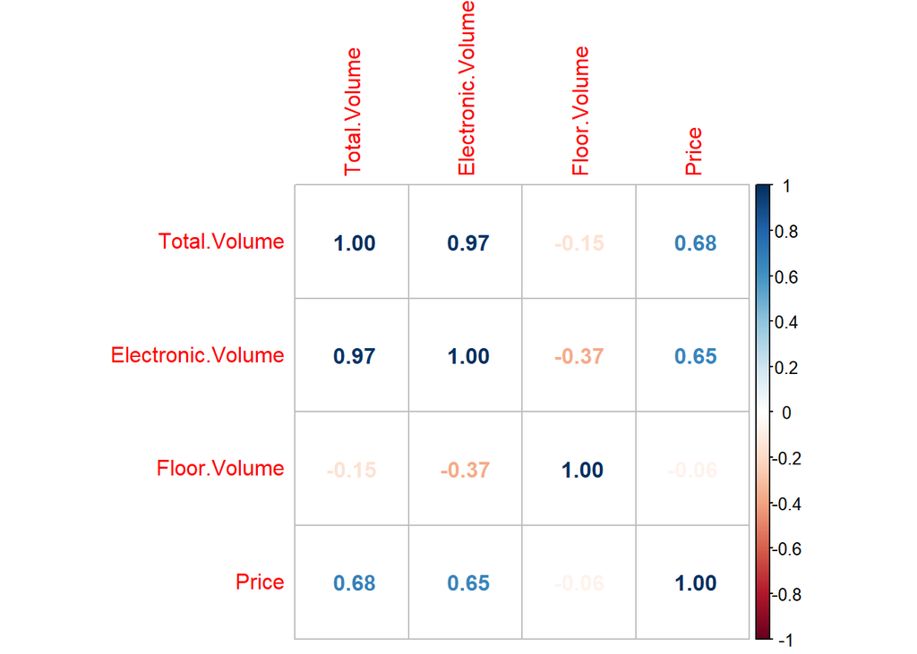

```r
# correlation matrices

corrplot(cor(na.omit(cme_df[, -c(1)])), method = "number")
```

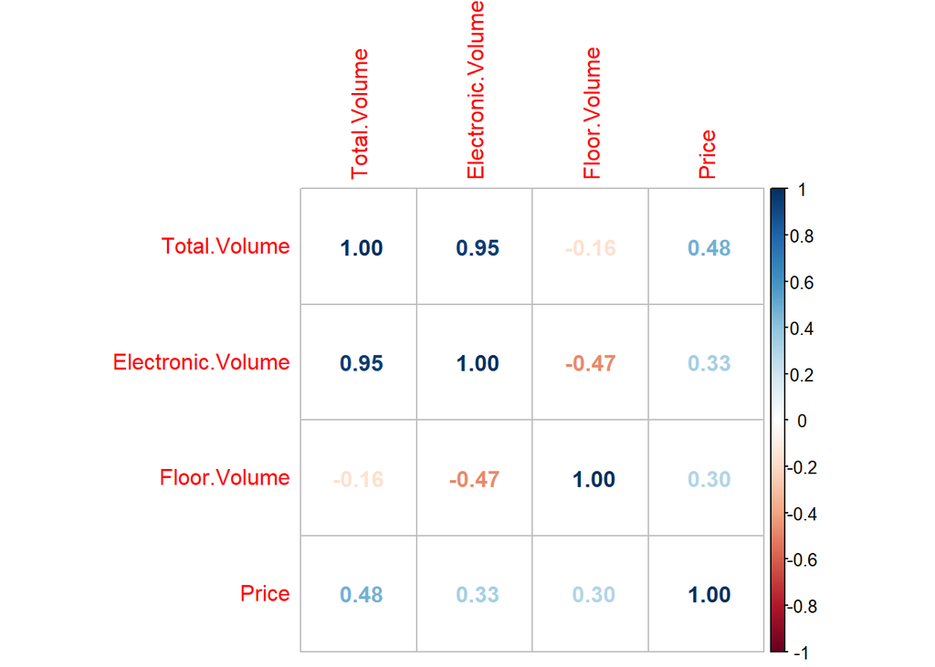

```r
corrplot(cor(na.omit(imm_df[, -c(1)])), method = "number")
```

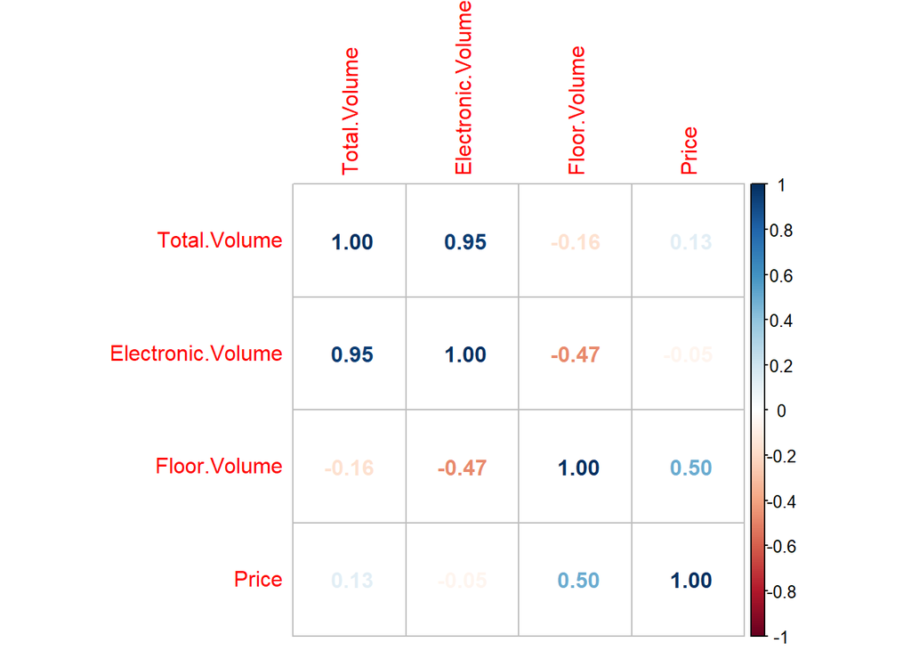

```r
corrplot(cor(na.omit(iom_df[, -c(1)])), method = "number")
```

For all 3 commodity indicators, electronic volume and total volume are highly correlated. To avoid multicolinearity, we will not use total volume as a predictor in our linear regression.

```r
# Fit lm
cme_model =  lm(Price ~ Electronic.Volume + Floor.Volume, data = na.omit(cme_train))
imm_model =  lm(Price ~ Electronic.Volume + Floor.Volume, data = na.omit(imm_train))
iom_model =  lm(Price ~ Electronic.Volume + Floor.Volume, data = na.omit(iom_train))
```

```r
print("CME Linear Regression")
```

```
## [1] "CME Linear Regression"
```

```r
summary(cme_model)
```

```
##
## Call:
## lm(formula = Price ~ Electronic.Volume + Floor.Volume, data = na.omit(cme_train))
##
## Residuals:
##     Min      1Q  Median      3Q     Max
## -398470 -124660  -10506   80518  786188
##
## Coefficients:
##                    Estimate Std. Error t value Pr(>|t|)
## (Intercept)       1.572e+05  6.544e+04   2.402   0.0176 *
## Electronic.Volume 2.923e-03  2.412e-04  12.121   <2e-16 ***
## Floor.Volume      2.120e-03  1.111e-03   1.908   0.0584 .
## ---
## Signif. codes:  0 '***' 0.001 '**' 0.01 '*' 0.05 '.' 0.1 ' ' 1
##
## Residual standard error: 199600 on 141 degrees of freedom
## Multiple R-squared:  0.5184, Adjusted R-squared:  0.5116
## F-statistic: 75.88 on 2 and 141 DF,  p-value: < 2.2e-16
```

```r
print("IMM Linear Regression")
```

```
## [1] "IMM Linear Regression"
```

```r
summary(imm_model)
```

```
##
## Call:
## lm(formula = Price ~ Electronic.Volume + Floor.Volume, data = na.omit(imm_train))
##
## Residuals:
##     Min      1Q  Median      3Q     Max
## -233572  -73354  -13602   50467  449612
##
## Coefficients:
##                    Estimate Std. Error t value Pr(>|t|)
## (Intercept)       1.218e+05  3.579e+04   3.404 0.000864 ***
## Electronic.Volume 3.785e-03  4.270e-04   8.864 3.04e-15 ***
## Floor.Volume      8.484e-03  1.405e-03   6.039 1.30e-08 ***
## ---
## Signif. codes:  0 '***' 0.001 '**' 0.01 '*' 0.05 '.' 0.1 ' ' 1
##
## Residual standard error: 119400 on 141 degrees of freedom
## Multiple R-squared:  0.3753, Adjusted R-squared:  0.3664
## F-statistic: 42.36 on 2 and 141 DF,  p-value: 3.931e-15
```

```r
print("IOM Linear Regression")
```

```
## [1] "IOM Linear Regression"
```

```r
summary(iom_model)
```

```
##
## Call:
## lm(formula = Price ~ Electronic.Volume + Floor.Volume, data = na.omit(iom_train))
##
## Residuals:
##     Min      1Q  Median      3Q     Max
## -154471  -68169  -24616   50368  450996
##
## Coefficients:
##                    Estimate Std. Error t value Pr(>|t|)
## (Intercept)       6.170e+04  2.921e+04   2.113  0.03641 *
## Electronic.Volume 1.123e-03  3.485e-04   3.222  0.00158 **
## Floor.Volume      7.127e-03  1.146e-03   6.217 5.41e-09 ***
## ---
## Signif. codes:  0 '***' 0.001 '**' 0.01 '*' 0.05 '.' 0.1 ' ' 1
##
## Residual standard error: 97460 on 141 degrees of freedom
## Multiple R-squared:  0.2168, Adjusted R-squared:  0.2057
## F-statistic: 19.51 on 2 and 141 DF,  p-value: 3.304e-08
```

```r
# Make predictions on the test sets
cme_pred =  predict(cme_model, newdata = cme_test)
imm_pred =  predict(imm_model, newdata = imm_test)
iom_pred =  predict(iom_model, newdata = iom_test)
```

```r
# Get R^2 for models
cme_r2 =  summary(lm(cme_test$Price ~ cme_pred))$r.squared
imm_r2 =  summary(lm(imm_test$Price ~ imm_pred))$r.squared
iom_r2 =  summary(lm(iom_test$Price ~ iom_pred))$r.squared
```

```r
cat("cme_model R^2: ", cme_r2, "\n")
```

```
## cme_model R^2:  0.06179205
```

```r
cat("imm_model R^2: ", imm_r2, "\n")
```

```
## imm_model R^2:  0.2345866
```

```r
cat("iom_model R^2: ", iom_r2, "\n")
```

```
## iom_model R^2:  0.3108456
```

```r
# Calculate RMSE
cme_rmse =  sqrt(mean((cme_test$Price - cme_pred)^2))
imm_rmse =  sqrt(mean((imm_test$Price - imm_pred)^2))
iom_rmse =  sqrt(mean((iom_test$Price - iom_pred)^2))
```

```r
cat("cme_model RMSE: ", cme_rmse, "\n")
```

```
## cme_model RMSE:  288319.5
```

```r
cat("imm_model RMSE: ", imm_rmse, "\n")
```

```
## imm_model RMSE:  319468.3
```

```r
cat("iom_model RMSE: ", iom_rmse, "\n")
```

```
## iom_model RMSE:  95326.78
```

## Linear Regression with ARMA Errors

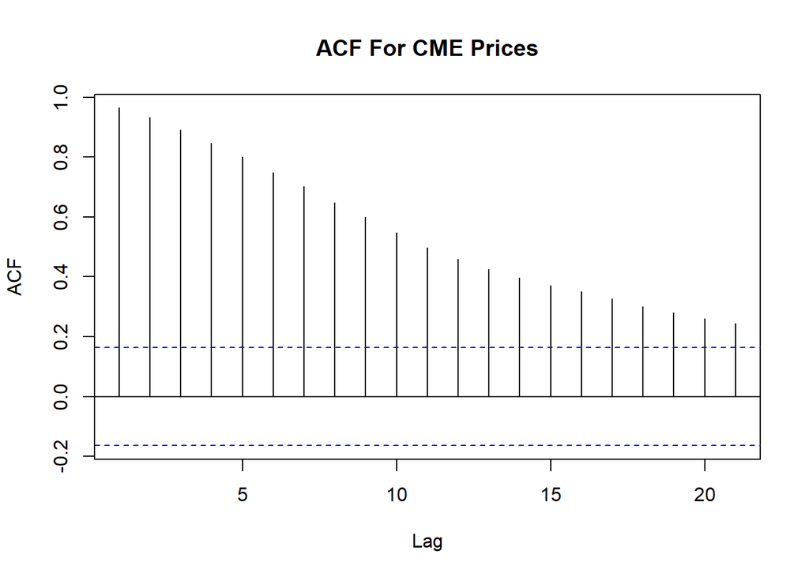

```r
acf(na.omit(cme_train$Price), main = "ACF For CME Prices")
```

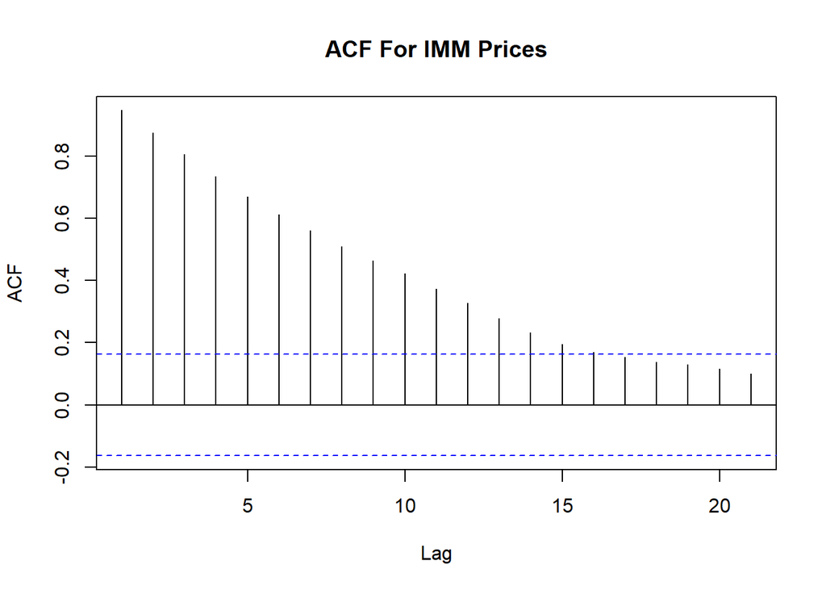

```r
acf(na.omit(imm_train$Price), main = "ACF For IMM Prices")
```

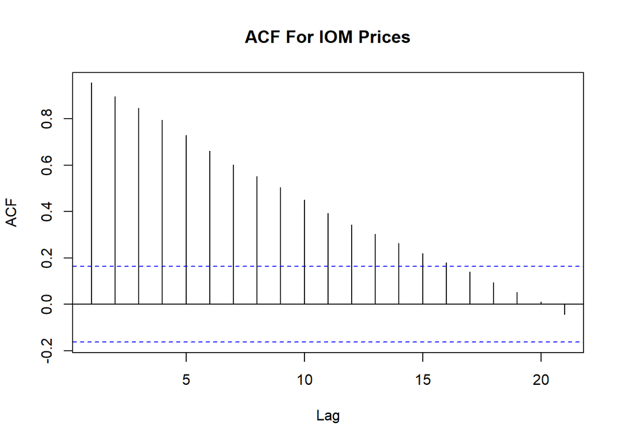

```r
acf(na.omit(iom_train$Price), main = "ACF For IOM Prices")
```

The lags for all commodity types have high correlations, so we need to difference the data for the arima model. We can use an auto arima model for this.

```r
# Fit ARMA model with xreg on resids using vols as external predictors
arma_cme =  auto.arima(cme_train$Price,
                    xreg = cbind(cme_train$Electronic.Volume, cme_train$Floor.Volume))
arma_imm =  auto.arima(imm_train$Price,
                    xreg = cbind(imm_train$Electronic.Volume, imm_train$Floor.Volume))
arma_iom =  auto.arima(iom_train$Price,
                    xreg = cbind(iom_train$Electronic.Volume, iom_train$Floor.Volume))
```

```r
print("CME Model")
```

```
## [1] "CME Model"
```

```r
summary(arma_cme)
```

```
## Series: cme_train$Price
## Regression with ARIMA(0,0,0) errors
##
## Coefficients:
##        xreg1   xreg2
##       0.0033  0.0045
## s.e.  0.0002  0.0005
##
## sigma^2 = 4.117e+10:  log likelihood = -1963.07
## AIC=3932.14   AICc=3932.31   BIC=3941.05
##
## Training set error measures:
##                    ME     RMSE      MAE       MPE     MAPE     MASE      ACF1
## Training set 10153.03 201488.3 148942.5 -3.418356 30.27306 3.624478 0.7140733
```

```r
print("IMM Model")
```

```
## [1] "IMM Model"
```

```r
summary(arma_imm)
```

```
## Series: imm_train$Price
## Regression with ARIMA(0,0,0) errors
##
## Coefficients:
##        xreg1   xreg2
##       0.0049  0.0127
## s.e.  0.0003  0.0007
##
## sigma^2 = 1.532e+10:  log likelihood = -1891.91
## AIC=3789.83   AICc=3790   BIC=3798.74
##
## Training set error measures:
##                    ME   RMSE      MAE       MPE     MAPE   MASE      ACF1
## Training set 9419.486 122928 91667.61 -1.383127 23.98788 3.5218 0.6018521
```

```r
print("IOM Model")
```

```
## [1] "IOM Model"
```

```r
summary(arma_iom)
```

```
## Series: iom_train$Price
## Regression with ARIMA(0,0,0) errors
##
## Coefficients:
##        xreg1   xreg2
##       0.0017  0.0092
## s.e.  0.0003  0.0006
##
## sigma^2 = 9.729e+09:  log likelihood = -1859.21
## AIC=3724.41   AICc=3724.58   BIC=3733.32
##
## Training set error measures:
##                    ME     RMSE      MAE       MPE     MAPE    MASE      ACF1
## Training set 4770.326 97950.49 74790.76 -7.191232 35.14678 4.08616 0.7722871
```

```r
# Forecast
for1_cme =  forecast(arma_cme,
                         xreg = cbind(cme_test$Electronic.Volume, cme_test$Floor.Volume),
                         h = 12)$mean
for1_imm =  forecast(arma_imm,
                         xreg = cbind(imm_test$Electronic.Volume, imm_test$Floor.Volume),
                         h = 12)$mean
for1_iom =  forecast(arma_iom,
                         xreg = cbind(iom_test$Electronic.Volume, iom_test$Floor.Volume),
                         h = 12)$mean
```

```r
# Calculate RMSE
cme_rmse =  sqrt(mean((cme_test$Price - for1_cme)^2))
imm_rmse =  sqrt(mean((imm_test$Price - for1_imm)^2))
iom_rmse =  sqrt(mean((iom_test$Price - for1_iom)^2))
```

```r
cat("cme_model RMSE: ", cme_rmse, "\n")
```

```
## cme_model RMSE:  257036.9
```

```r
cat("imm_model RMSE: ", imm_rmse, "\n")
```

```
## imm_model RMSE:  280126.9
```

```r
cat("iom_model RMSE: ", iom_rmse, "\n")
```

```
## iom_model RMSE:  77186.32
```

## Holt Winters

```r
# Make ts for the hw model
cme_ts =  ts(na.omit(cme_train$Price), frequency = 12, start = c(2001, 1))
imm_ts =  ts(na.omit(imm_train$Price), frequency = 12, start = c(2001, 1))
iom_ts =  ts(na.omit(iom_train$Price), frequency = 12, start = c(2001, 1))

# Fit HW model
hw_cme =  HoltWinters(cme_ts, seasonal = "multiplicative")
hw_imm =  HoltWinters(imm_ts, seasonal = "multiplicative")
hw_iom =  HoltWinters(iom_ts, seasonal = "multiplicative")
```

```r
print("CME Model")
```

```
## [1] "CME Model"
```

```r
print(hw_cme)
```

```
## Holt-Winters exponential smoothing with trend and multiplicative seasonal component.
##
## Call:
## HoltWinters(x = cme_ts, seasonal = "multiplicative")
##
## Smoothing parameters:
##  alpha: 0.8228917
##  beta : 0
##  gamma: 1
##
## Coefficients:
##             [,1]
## a   4.517910e+05
## b   4.759178e+03
## s1  9.439880e-01
## s2  9.647071e-01
## s3  9.623374e-01
## s4  9.536895e-01
## s5  9.561518e-01
## s6  9.758176e-01
## s7  9.530074e-01
## s8  9.790403e-01
## s9  1.024283e+00
## s10 1.037566e+00
## s11 9.367506e-01
## s12 9.274200e-01
```

```r
print("IMM Model")
```

```
## [1] "IMM Model"
```

```r
print(hw_imm)
```

```
## Holt-Winters exponential smoothing with trend and multiplicative seasonal component.
##
## Call:
## HoltWinters(x = imm_ts, seasonal = "multiplicative")
##
## Smoothing parameters:
##  alpha: 0.9139717
##  beta : 0.00679701
##  gamma: 1
##
## Coefficients:
##             [,1]
## a   1.882483e+05
## b   1.095110e+01
## s1  9.593459e-01
## s2  9.939973e-01
## s3  9.943739e-01
## s4  1.010016e+00
## s5  9.887150e-01
## s6  1.010014e+00
## s7  1.024844e+00
## s8  1.053776e+00
## s9  1.036780e+00
## s10 9.468573e-01
## s11 8.867639e-01
## s12 9.030628e-01
```

```r
print("IOM Model")
```

```
## [1] "IOM Model"
```

```r
print(hw_iom)
```

```
## Holt-Winters exponential smoothing with trend and multiplicative seasonal component.
##
## Call:
## HoltWinters(x = iom_ts, seasonal = "multiplicative")
##
## Smoothing parameters:
##  alpha: 1
##  beta : 0.00280551
##  gamma: 0
##
## Coefficients:
##             [,1]
## a   6.676809e+04
## b   9.596732e+02
## s1  1.045625e+00
## s2  1.076393e+00
## s3  1.047942e+00
## s4  1.019786e+00
## s5  1.004187e+00
## s6  9.919600e-01
## s7  1.074445e+00
## s8  1.030497e+00
## s9  9.276192e-01
## s10 8.891184e-01
## s11 9.338859e-01
## s12 9.585418e-01
```

```r
# Forecast
hw_for_cme =  forecast(hw_cme, h = 12)$mean
hw_for_imm =  forecast(hw_imm, h = 12)$mean
hw_for_iom =  forecast(hw_iom, h = 12)$mean
```

```r
cme_rmse =  sqrt(mean((cme_test$Price - hw_for_cme)^2))
imm_rmse =  sqrt(mean((imm_test$Price - hw_for_imm)^2))
iom_rmse =  sqrt(mean((iom_test$Price - hw_for_iom)^2))
```

```r
cat("cme_model RMSE: ", cme_rmse, "\n")
```

```
## cme_model RMSE:  66312.61
```

```r
cat("imm_model RMSE: ", imm_rmse, "\n")
```

```
## imm_model RMSE:  124475.6
```

```r
cat("iom_model RMSE: ", iom_rmse, "\n")
```

```
## iom_model RMSE:  15530.57
```

## ARIMA

```r
# Fit ARMA model
arma_cme =  auto.arima(cme_train$Price)
arma_imm =  auto.arima(imm_train$Price)
arma_iom =  auto.arima(iom_train$Price)
```

```r
print("CME Model")
```

```
## [1] "CME Model"
```

```r
summary(arma_cme)
```

```
## Series: cme_train$Price
## ARIMA(0,1,0)
##
## sigma^2 = 4.531e+09:  log likelihood = -1792.66
## AIC=3587.31   AICc=3587.34   BIC=3590.27
##
## Training set error measures:
##                    ME     RMSE      MAE       MPE     MAPE     MASE        ACF1
## Training set 1605.472 67079.46 40369.36 0.9454879 7.081229 0.982378 -0.02736309
```

```r
print("IMM Model")
```

```
## [1] "IMM Model"
```

```r
summary(arma_imm)
```

```
## Series: imm_train$Price
## ARIMA(1,1,0)
##
## Coefficients:
##          ar1
##       0.3094
## s.e.  0.0795
##
## sigma^2 = 1.495e+09:  log likelihood = -1712.93
## AIC=3429.86   AICc=3429.94   BIC=3435.78
##
## Training set error measures:
##                     ME     RMSE      MAE         MPE     MAPE      MASE
## Training set -108.2639 38397.46 25231.74 -0.01883883 6.296225 0.9693841
##                     ACF1
## Training set 0.009578673
```

```r
print("IOM Model")
```

```
## [1] "IOM Model"
```

```r
summary(arma_iom)
```

```
## Series: iom_train$Price
## ARIMA(0,1,1)
##
## Coefficients:
##          ma1
##       0.2967
## s.e.  0.0810
##
## sigma^2 = 767755853:  log likelihood = -1665.27
## AIC=3334.54   AICc=3334.63   BIC=3340.47
##
## Training set error measures:
##                     ME     RMSE      MAE        MPE     MAPE      MASE
## Training set -362.9206 27515.32 16694.61 0.02375126 7.392782 0.9121027
##                     ACF1
## Training set -0.01649923
```

```r
# Forecast
for2_cme =  forecast(arma_cme, h = 12)$mean
for2_imm =  forecast(arma_imm, h = 12)$mean
for2_iom =  forecast(arma_iom, h = 12)$mean
```

```r
# Calculate RMSE
cme_rmse =  sqrt(mean((cme_test$Price - for2_cme)^2))
imm_rmse =  sqrt(mean((imm_test$Price - for2_imm)^2))
iom_rmse =  sqrt(mean((iom_test$Price - for2_iom)^2))
```

```r
cat("cme_model RMSE: ", cme_rmse, "\n")
```

```
## cme_model RMSE:  73601.4
```

```r
cat("imm_model RMSE: ", imm_rmse, "\n")
```

```
## imm_model RMSE:  102439.4
```

```r
cat("iom_model RMSE: ", iom_rmse, "\n")
```

```
## iom_model RMSE:  10624.93
```

## Seasonal ARIMA

```r
# Show seasonal decomposition
cme_ets = ets(cme_ts)
print("CME Decomposition")
```

```
## [1] "CME Decomposition"
```

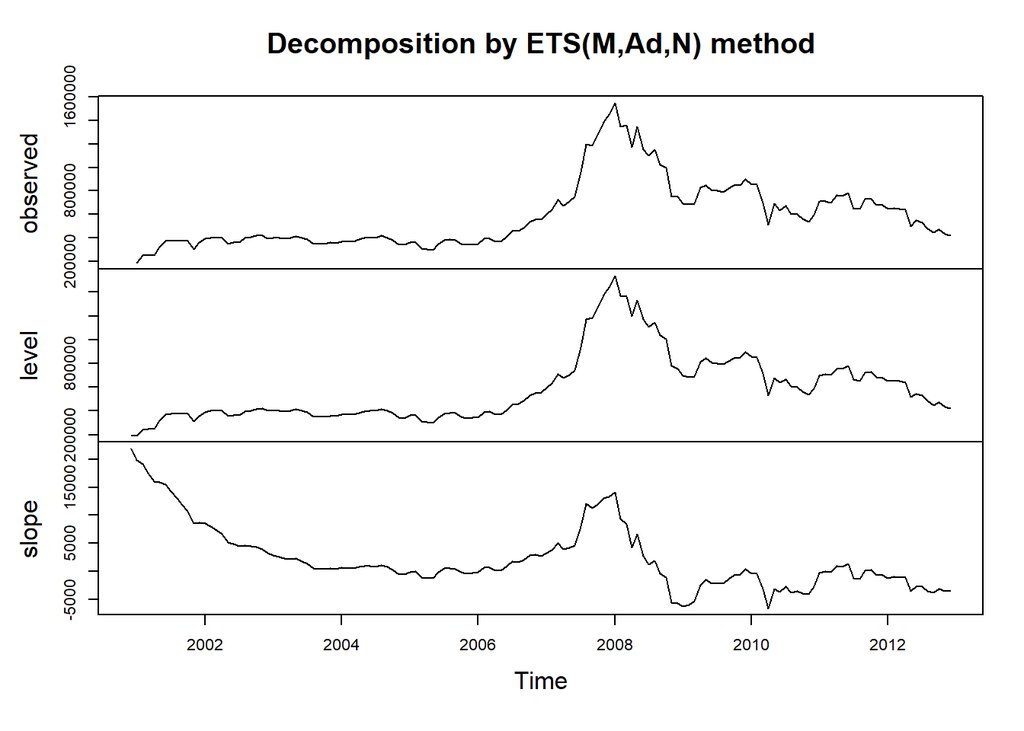

```r
plot(cme_ets)
```

```r
imm_ets = ets(imm_ts)
print("IMM Decomposition")
```

```
## [1] "IMM Decomposition"
```

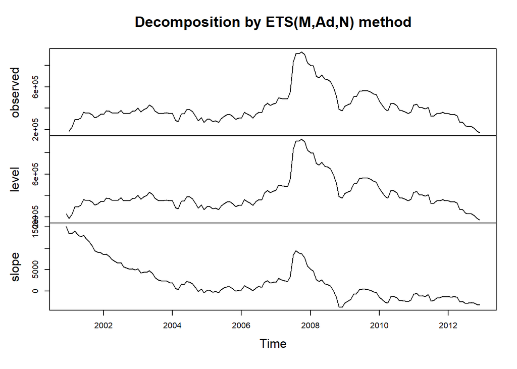

```r
plot(imm_ets)
```

```r
iom_ets = ets(iom_ts)
print("IOM Decomposition")
```

```
## [1] "IOM Decomposition"
```

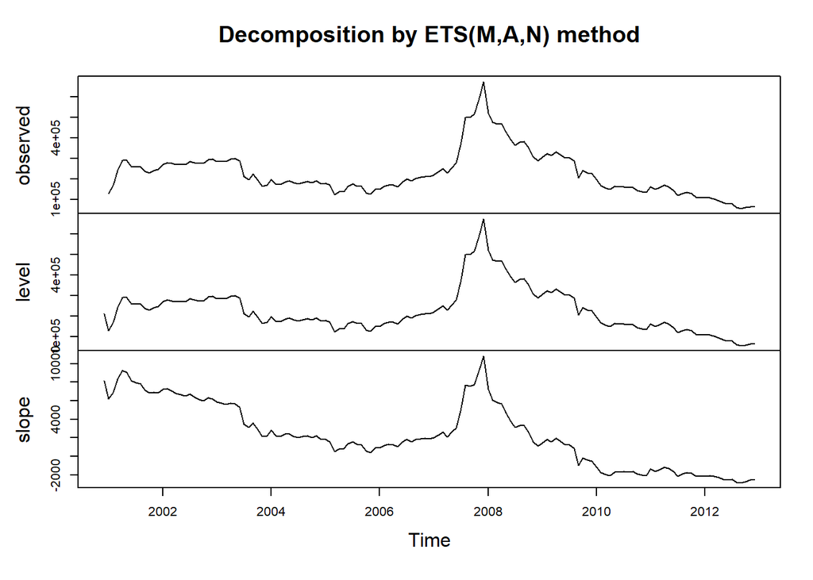

```r
plot(iom_ets)
```

For all three commodity groups, the seasonal decompistion graphs do not show a repetitive trend so there may not be a huge seasonal component that the season arima model can capture.

```r
# Fit ARMA model
arma_cme =  auto.arima(cme_train$Price, seasonal = TRUE)
arma_imm =  auto.arima(imm_train$Price, seasonal = TRUE)
arma_iom =  auto.arima(iom_train$Price, seasonal = TRUE)
```

```r
print("CME Model")
```

```
## [1] "CME Model"
```

```r
summary(arma_cme)
```

```
## Series: cme_train$Price
## ARIMA(0,1,0)
##
## sigma^2 = 4.531e+09:  log likelihood = -1792.66
## AIC=3587.31   AICc=3587.34   BIC=3590.27
##
## Training set error measures:
##                    ME     RMSE      MAE       MPE     MAPE     MASE        ACF1
## Training set 1605.472 67079.46 40369.36 0.9454879 7.081229 0.982378 -0.02736309
```

```r
print("IMM Model")
```

```
## [1] "IMM Model"
```

```r
summary(arma_imm)
```

```
## Series: imm_train$Price
## ARIMA(1,1,0)
##
## Coefficients:
##          ar1
##       0.3094
## s.e.  0.0795
##
## sigma^2 = 1.495e+09:  log likelihood = -1712.93
## AIC=3429.86   AICc=3429.94   BIC=3435.78
##
## Training set error measures:
##                     ME     RMSE      MAE         MPE     MAPE      MASE
## Training set -108.2639 38397.46 25231.74 -0.01883883 6.296225 0.9693841
##                     ACF1
## Training set 0.009578673
```

```r
print("IOM Model")
```

```
## [1] "IOM Model"
```

```r
summary(arma_iom)
```

```
## Series: iom_train$Price
## ARIMA(0,1,1)
##
## Coefficients:
##          ma1
##       0.2967
## s.e.  0.0810
##
## sigma^2 = 767755853:  log likelihood = -1665.27
## AIC=3334.54   AICc=3334.63   BIC=3340.47
##
## Training set error measures:
##                     ME     RMSE      MAE        MPE     MAPE      MASE
## Training set -362.9206 27515.32 16694.61 0.02375126 7.392782 0.9121027
##                     ACF1
## Training set -0.01649923
```

```r
# Forecast
seas_for_cme =  forecast(arma_cme, h = 12)$mean
seas_for_imm =  forecast(arma_imm, h = 12)$mean
seas_for_iom =  forecast(arma_iom, h = 12)$mean
```

```r
# Calculate RMSE
cme_rmse =  sqrt(mean((cme_test$Price - seas_for_cme)^2))
imm_rmse =  sqrt(mean((imm_test$Price - seas_for_imm)^2))
iom_rmse =  sqrt(mean((iom_test$Price - seas_for_iom)^2))
```

```r
cat("cme_model RMSE: ", cme_rmse, "\n")
```

```
## cme_model RMSE:  73601.4
```

```r
cat("imm_model RMSE: ", imm_rmse, "\n")
```

```
## imm_model RMSE:  102439.4
```

```r
cat("iom_model RMSE: ", iom_rmse, "\n")
```

```
## iom_model RMSE:  10624.93
```

## ARFIMA

The ACF plots showed slow decay in the autocorrelations for all three commodities, so the ARFIMA model is valid to use in this scenario.

```r
cme_mod = fracdiff(cme_ts)
imm_mod = fracdiff(imm_ts)
iom_mod = fracdiff(iom_ts)
```

```r
print("CME Model")
```

```
## [1] "CME Model"
```

```r
summary(cme_mod)
```

```
##
## Call:
##   fracdiff(x = cme_ts)
##
## Coefficients:
##    Estimate Std. Error z value Pr(>|z|)
## d 4.980e-01  1.957e-05   25442   <2e-16 ***
## ---
## Signif. codes:  0 '***' 0.001 '**' 0.01 '*' 0.05 '.' 0.1 ' ' 1
## sigma[eps] = 96586.46
## [d.tol = 0.0001221, M = 100, h = 1.961e-05]
## Log likelihood: -1860 ==> AIC = 3724.046 [2 deg.freedom]
```

```r
print("IMM Model")
```

```
## [1] "IMM Model"
```

```r
summary(imm_mod)
```

```
##
## Call:
##   fracdiff(x = imm_ts)
##
## Coefficients:
##    Estimate Std. Error z value Pr(>|z|)
## d 4.987e-01  1.881e-05   26508   <2e-16 ***
## ---
## Signif. codes:  0 '***' 0.001 '**' 0.01 '*' 0.05 '.' 0.1 ' ' 1
## sigma[eps] = 58324.08
## [d.tol = 0.0001221, M = 100, h = 1.885e-05]
## Log likelihood: -1788 ==> AIC = 3579.182 [2 deg.freedom]
```

```r
print("IOM Model")
```

```
## [1] "IOM Model"
```

```r
summary(iom_mod)
```

```
##
## Call:
##   fracdiff(x = iom_ts)
##
## Coefficients:
##    Estimate Std. Error z value Pr(>|z|)
## d 4.995e-01  1.819e-05   27456   <2e-16 ***
## ---
## Signif. codes:  0 '***' 0.001 '**' 0.01 '*' 0.05 '.' 0.1 ' ' 1
## sigma[eps] = 38679.71
## [d.tol = 0.0001221, M = 100, h = 1.823e-05]
## Log likelihood: -1729 ==> AIC = 3461.853 [2 deg.freedom]
```

```r
# Forecast
frac_for_cme =  forecast(cme_mod, h = 12)$mean
frac_for_imm =  forecast(imm_mod, h = 12)$mean
frac_for_iom =  forecast(iom_mod, h = 12)$mean
```

```r
# Calculate RMSE
cme_rmse =  sqrt(mean((cme_test$Price - frac_for_cme)^2))
imm_rmse =  sqrt(mean((imm_test$Price - frac_for_imm)^2))
iom_rmse =  sqrt(mean((iom_test$Price - frac_for_iom)^2))
```

```r
cat("cme_model RMSE: ", cme_rmse, "\n")
```

```
## cme_model RMSE:  107646.2
```

```r
cat("imm_model RMSE: ", imm_rmse, "\n")
```

```
## imm_model RMSE:  230265.7
```

```r
cat("iom_model RMSE: ", iom_rmse, "\n")
```

```
## iom_model RMSE:  65447.37
```

## GARCH Model

```r
adf.test(cme_ts)
```

```
##
##  Augmented Dickey-Fuller Test
##
## data:  cme_ts
## Dickey-Fuller = -2.2769, Lag order = 5, p-value = 0.4611
## alternative hypothesis: stationary
```

```r
adf.test(imm_ts)
```

```
##
##  Augmented Dickey-Fuller Test
##
## data:  imm_ts
## Dickey-Fuller = -1.5481, Lag order = 5, p-value = 0.7646
## alternative hypothesis: stationary
```

```r
adf.test(iom_ts)
```

```
##
##  Augmented Dickey-Fuller Test
##
## data:  iom_ts
## Dickey-Fuller = -2.0869, Lag order = 5, p-value = 0.5402
## alternative hypothesis: stationary
```

```r
cme_log = log(cme_ts)
imm_log = log(imm_ts)
iom_log = log(iom_ts)
```

```r
cme_log = diff(cme_log)
imm_log = diff(imm_log)
iom_log = diff(iom_log)
```

```r
adf.test(cme_log)
```

```
##
##  Augmented Dickey-Fuller Test
##
## data:  cme_log
## Dickey-Fuller = -4.5515, Lag order = 5, p-value = 0.01
## alternative hypothesis: stationary
```

```r
adf.test(imm_log)
```

```
##
##  Augmented Dickey-Fuller Test
##
## data:  imm_log
## Dickey-Fuller = -5.211, Lag order = 5, p-value = 0.01
## alternative hypothesis: stationary
```

```r
adf.test(iom_log)
```

```
##
##  Augmented Dickey-Fuller Test
##
## data:  iom_log
## Dickey-Fuller = -4.7001, Lag order = 5, p-value = 0.01
## alternative hypothesis: stationary
```

Before differencing the time series for all three commodities were not stationary, after differencing and applying a log transformation they are stationary so we can proceed with the GARCH models as they require a stationary time series. Note, we take the log to prevent errors in the GARCH model.

```r
# Fit ARIMA models
arma_cme =  auto.arima(cme_log)
arma_imm =  auto.arima(imm_log)
arma_iom =  auto.arima(iom_log)
```

```r
# Use resids from ARIMAs to fit GARCHs
resids_cme =  residuals(arma_cme)
garch_cme =  garchFit(~ garch(1, 1), data = resids_cme, trace = F)
```

```r
# For IMM model
resids_imm =  residuals(arma_imm)
garch_imm =  garchFit(~ garch(1, 1), data = resids_imm, trace = F)
```

```r
# For IOM model
resids_iom =  residuals(arma_iom)
garch_iom =  garchFit(~ garch(1, 1), data = resids_iom, trace = F)
```

```r
print("CME Model")
```

```
## [1] "CME Model"
```

```r
summary(garch_cme)
```

```
##
## Title:
##  GARCH Modelling
##
## Call:
##  garchFit(formula = ~garch(1, 1), data = resids_cme, trace = F)
##
## Mean and Variance Equation:
##  data ~ garch(1, 1)
## <environment: 0x0000026243b09530>
##  [data = resids_cme]
##
## Conditional Distribution:
##  norm
##
## Coefficient(s):
##         mu       omega      alpha1       beta1
## 0.00386478  0.00099392  0.09176234  0.79457029
##
## Std. Errors:
##  based on Hessian
##
## Error Analysis:
##         Estimate  Std. Error  t value Pr(>|t|)
## mu     0.0038648   0.0078723    0.491 0.623472
## omega  0.0009939   0.0016055    0.619 0.535857
## alpha1 0.0917623   0.0613454    1.496 0.134698
## beta1  0.7945703   0.2168253    3.665 0.000248 ***
## ---
## Signif. codes:  0 '***' 0.001 '**' 0.01 '*' 0.05 '.' 0.1 ' ' 1
##
## Log Likelihood:
##  134.3956    normalized:  0.9398295
##
## Description:
##  Thu Mar  6 12:00:48 2025 by user: anush
##
##
## Standardised Residuals Tests:
##                                  Statistic      p-Value
##  Jarque-Bera Test   R    Chi^2  23.5922121 7.533837e-06
##  Shapiro-Wilk Test  R    W       0.9434165 1.527449e-05
##  Ljung-Box Test     R    Q(10)   6.6472613 7.582730e-01
##  Ljung-Box Test     R    Q(15)  10.3857777 7.947976e-01
##  Ljung-Box Test     R    Q(20)  12.7096048 8.894930e-01
##  Ljung-Box Test     R^2  Q(10)   5.1935267 8.778808e-01
##  Ljung-Box Test     R^2  Q(15)   7.2777705 9.494784e-01
##  Ljung-Box Test     R^2  Q(20)  16.9193084 6.582069e-01
##  LM Arch Test       R    TR^2    5.9440989 9.188737e-01
##
## Information Criterion Statistics:
##       AIC       BIC       SIC      HQIC
## -1.823715 -1.740838 -1.825224 -1.790038
```

```r
print("IMM Model")
```

```
## [1] "IMM Model"
```

```r
summary(garch_imm)
```

```
##
## Title:
##  GARCH Modelling
##
## Call:
##  garchFit(formula = ~garch(1, 1), data = resids_imm, trace = F)
##
## Mean and Variance Equation:
##  data ~ garch(1, 1)
## <environment: 0x00000262440900a0>
##  [data = resids_imm]
##
## Conditional Distribution:
##  norm
##
## Coefficient(s):
##          mu        omega       alpha1        beta1
## -0.00068379   0.00133553   0.00000001   0.82436373
##
## Std. Errors:
##  based on Hessian
##
## Error Analysis:
##          Estimate  Std. Error  t value Pr(>|t|)
## mu     -6.838e-04   7.448e-03   -0.092   0.9269
## omega   1.336e-03   6.026e-04    2.216   0.0267 *
## alpha1  1.000e-08         NaN      NaN      NaN
## beta1   8.244e-01         NaN      NaN      NaN
## ---
## Signif. codes:  0 '***' 0.001 '**' 0.01 '*' 0.05 '.' 0.1 ' ' 1
##
## Log Likelihood:
##  142.9749    normalized:  0.9998248
##
## Description:
##  Thu Mar  6 12:00:48 2025 by user: anush
##
##
## Standardised Residuals Tests:
##                                  Statistic      p-Value
##  Jarque-Bera Test   R    Chi^2  43.9795735 2.818104e-10
##  Shapiro-Wilk Test  R    W       0.9549209 1.284276e-04
##  Ljung-Box Test     R    Q(10)   5.8740074 8.257351e-01
##  Ljung-Box Test     R    Q(15)  10.3632542 7.962896e-01
##  Ljung-Box Test     R    Q(20)  14.4036545 8.094544e-01
##  Ljung-Box Test     R^2  Q(10)   3.8400949 9.542724e-01
##  Ljung-Box Test     R^2  Q(15)   5.7555655 9.835676e-01
##  Ljung-Box Test     R^2  Q(20)  15.7284805 7.333195e-01
##  LM Arch Test       R    TR^2    6.1584138 9.078867e-01
##
## Information Criterion Statistics:
##       AIC       BIC       SIC      HQIC
## -1.943706 -1.860829 -1.945214 -1.910028
```

```r
print("IOM Model")
```

```
## [1] "IOM Model"
```

```r
summary(garch_iom)
```

```
##
## Title:
##  GARCH Modelling
##
## Call:
##  garchFit(formula = ~garch(1, 1), data = resids_iom, trace = F)
##
## Mean and Variance Equation:
##  data ~ garch(1, 1)
## <environment: 0x0000026242e8cba8>
##  [data = resids_iom]
##
## Conditional Distribution:
##  norm
##
## Coefficient(s):
##         mu       omega      alpha1       beta1
## -0.0079233   0.0082767   0.1839423   0.0223500
##
## Std. Errors:
##  based on Hessian
##
## Error Analysis:
##         Estimate  Std. Error  t value Pr(>|t|)
## mu     -0.007923    0.008753   -0.905    0.365
## omega   0.008277    0.005417    1.528    0.127
## alpha1  0.183942    0.114777    1.603    0.109
## beta1   0.022350    0.494047    0.045    0.964
##
## Log Likelihood:
##  126.0642    normalized:  0.8815681
##
## Description:
##  Thu Mar  6 12:00:48 2025 by user: anush
##
##
## Standardised Residuals Tests:
##                                  Statistic      p-Value
##  Jarque-Bera Test   R    Chi^2  25.4573754 2.964839e-06
##  Shapiro-Wilk Test  R    W       0.9591341 2.979945e-04
##  Ljung-Box Test     R    Q(10)   6.0277308 8.129281e-01
##  Ljung-Box Test     R    Q(15)   8.8990571 8.827360e-01
##  Ljung-Box Test     R    Q(20)  21.9063716 3.456127e-01
##  Ljung-Box Test     R^2  Q(10)   3.9040819 9.515703e-01
##  Ljung-Box Test     R^2  Q(15)   7.8368107 9.301583e-01
##  Ljung-Box Test     R^2  Q(20)  14.1693210 8.218082e-01
##  LM Arch Test       R    TR^2    6.5698760 8.846815e-01
##
## Information Criterion Statistics:
##       AIC       BIC       SIC      HQIC
## -1.707192 -1.624315 -1.708701 -1.673515
```

```r
# Forecast by taking arma price prediction + garch volaity prediction
tmp_cme = forecast(arma_cme, h = 12)$mean
g_for_cme =  predict(garch_cme, n.ahead = 12)$standardDeviation + tmp_cme
g_for_cme = exp(g_for_cme)

tmp_imm = forecast(arma_imm, h = 12)$mean
g_for_imm =  predict(garch_imm, n.ahead = 12)$standardDeviation + tmp_imm
g_for_imm = exp(g_for_imm)

tmp_iom = forecast(arma_iom, h = 12)$mean
g_for_iom =  predict(garch_iom, n.ahead = 12)$standardDeviation + tmp_iom
g_for_iom = exp(g_for_iom)
```

```r
# Calculate RMSE
rmse_cme =  sqrt(mean((cme_test$Price - g_for_cme)^2))
rmse_imm =  sqrt(mean((imm_test$Price - g_for_imm)^2))
rmse_iom =  sqrt(mean((iom_test$Price - g_for_iom)^2))
```

```r
cat("CME Model RMSE: ", rmse_cme, "\n")
```

```
## CME Model RMSE:  456532.2
```

```r
cat("IMM Model RMSE: ", rmse_imm, "\n")
```

```
## IMM Model RMSE:  63033.85
```

```r
cat("IOM Model RMSE: ", rmse_iom, "\n")
```

```
## IOM Model RMSE:  63033.82
```

## Plot forecasts onto one plot for comparison

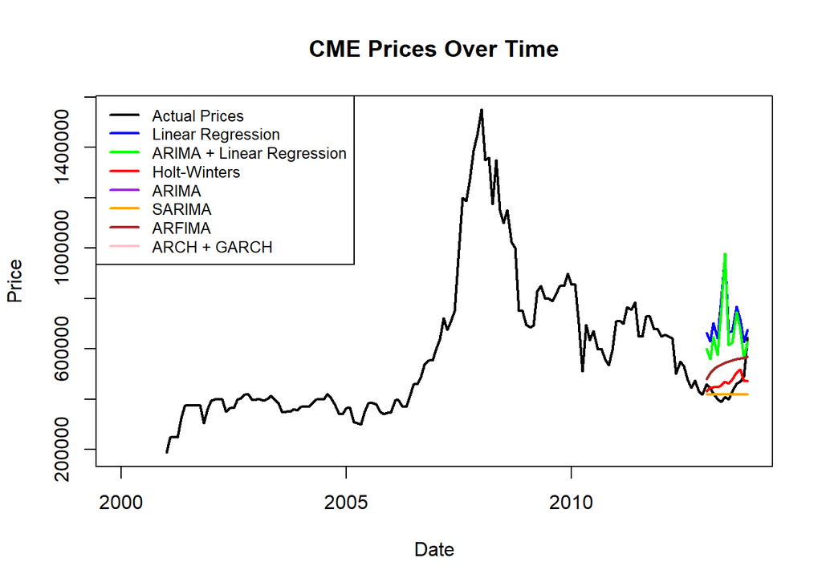

```r
cme_2013 =  cme_df[cme_df$Date >= "2013-01-01" & cme_df$Date <= "2013-12-31",]

plot(cme_df$Date, cme_df$Price, type = "l", col = "black", lwd = 2,
     xlab = "Date", ylab = "Price",
     main = "CME Prices Over Time")

lines(cme_2013$Date, cme_pred, col = "blue", lwd = 2)
lines(cme_2013$Date, for1_cme, col = "green", lwd = 2)
lines(cme_2013$Date, hw_for_cme, col = "red", lwd = 2)
lines(cme_2013$Date, for2_cme, col = "purple", lwd = 2)
lines(cme_2013$Date, seas_for_cme, col = "orange", lwd = 2)
lines(cme_2013$Date, frac_for_cme, col = "brown", lwd = 2)
lines(cme_2013$Date, g_for_cme, col = "pink", lwd = 2)

legend("topleft", legend = c("Actual Prices", "Linear Regression", "ARIMA + Linear Regression",
                             "Holt-Winters", "ARIMA", "SARIMA", "ARFIMA", "ARCH + GARCH"),
       col = c("black", "blue", "green", "red", "purple", "orange", "brown", "pink"),
       lty = 1, lwd = 2, cex = 0.8)
```

We note that the SARIMA and ARIMA models returned the same forecasts. All 7 models did not closely predict the 2013 prices, having high RMSEs. However, SARIMA, ARIMA, and Holt-Winters estimated the prices the most closely.

# Task B

```r
sts = read.csv("sts_data_2023.csv")
head(sts)
```

```
##       Date Mean_GC Mean_CPI Mean_CL Mean_SPX
## 1  3/31/50   40.15   -1.460    2.57   17.130
## 2  6/30/50   37.75   -0.840    2.57   18.370
## 3  9/30/50   39.15    1.895    2.57   18.065
## 4 12/31/50   39.20    4.855    2.57   19.715
## 5  3/31/51   42.90    8.725    2.57   21.450
## 6  6/30/51   41.90    9.070    2.57   21.885
```

```r
# Get df for each fit time period
sts$Date = as.Date(sts$Date, format = "%m/%d/%y")

# Train dfs
train1 = na.omit(sts[sts$Date <= as.Date("1979-06-30"),])
train2 = na.omit(sts[sts$Date <= as.Date("2004-06-30"),])
train3 = na.omit(sts[sts$Date <= as.Date("2022-12-31"),])

# Test dfs --> one period = 3 months
test1 = na.omit(sts[sts$Date >= as.Date("1979-09-30") & sts$Date <= as.Date("1980-09-30"),])
test2 = na.omit(sts[sts$Date >= as.Date("2004-09-30") & sts$Date <= as.Date("2005-09-30"),])
# 3/2023 last date in df so just look at one quarter for testing
test3 = na.omit(sts[sts$Date >= as.Date("2023-03-31") & sts$Date <= as.Date("2024-06-30"),])
```

## Dynamic Regression With Lagged Predictors

```r
# Fit BSTS model with dynamic regression
fit_bsts_dynamic_regression = function(train_data, y_variable, x_variables) {

  # Lag predictors
  for (x in x_variables) {
    train_data[[paste0(x, "_lag_1")]] = c(NA, train_data[[x]][1:(nrow(train_data) - 1)]) # Lag 1
  }

  # Remove NAs --> model throws an error
  train_data = na.omit(train_data)
  y = train_data[[y_variable]]
  X = train_data[, c(x_variables, paste0(x_variables, "_lag_1"))]

  # State specification
  state_specification = AddLocalLinearTrend(list(), y)

  # Fit model
  model = bsts(y ~ ., state.specification = state_specification, data = cbind(X, y), niter = 1000)

  return(model)
}
```

```r
# Dynamic Regression for GC
dr_GC_1 = fit_bsts_dynamic_regression(train1, "Mean_GC", c("Mean_CPI", "Mean_CL", "Mean_SPX"))
```

[output not shown]

```r
dr_GC_2 = fit_bsts_dynamic_regression(train2, "Mean_GC", c("Mean_CPI", "Mean_CL", "Mean_SPX"))
```

[output not shown]

```r
dr_GC_3 = fit_bsts_dynamic_regression(train3, "Mean_GC", c("Mean_CPI", "Mean_CL", "Mean_SPX"))
```

[output not shown]

```r
# Dynamic Regression for CL
dr_CL_1 = fit_bsts_dynamic_regression(train1, "Mean_CL", c("Mean_CPI", "Mean_GC", "Mean_SPX"))
```

[output not shown]

```r
dr_CL_2 = fit_bsts_dynamic_regression(train2, "Mean_CL", c("Mean_CPI", "Mean_GC", "Mean_SPX"))
```

[output not shown]

```r
dr_CL_3 = fit_bsts_dynamic_regression(train3, "Mean_CL", c("Mean_CPI", "Mean_GC", "Mean_SPX"))
```

[output not shown]

```r
# Forecasts
# Need to make a function to lag the variables in test as well
create_lagged_predictors = function(test_data, x_variables) {
  for (x in x_variables) {
    test_data[[paste0(x, "_lag_1")]] = c(NA, test_data[[x]][1:(nrow(test_data) - 1)]) # Lag 1
  }

  test_data = na.omit(test_data)

  return(test_data)
}
```

```r
# Lag tests for GC
test1_lagged = create_lagged_predictors(test1, c("Mean_CPI", "Mean_CL", "Mean_SPX"))
test2_lagged = create_lagged_predictors(test2, c("Mean_CPI", "Mean_CL", "Mean_SPX"))
# need to replicate test3 df row so we can do the lag
test3_lagged = create_lagged_predictors(test3[rep(1,2),], c("Mean_CPI", "Mean_CL", "Mean_SPX"))
```

```r
# Forecast GC
pred_GC_1 = predict(dr_GC_1, newdata = test1_lagged)$mean
pred_GC_2 = predict(dr_GC_2, newdata = test2_lagged)$mean
pred_GC_3 = predict(dr_GC_3, newdata = test3_lagged)$mean
```

```r
# Lag tests for CL
test1_lagged = create_lagged_predictors(test1, c("Mean_CPI", "Mean_GC", "Mean_SPX"))
test2_lagged = create_lagged_predictors(test2, c("Mean_CPI", "Mean_GC", "Mean_SPX"))
test3_lagged = create_lagged_predictors(test3[rep(1,2),], c("Mean_CPI", "Mean_GC", "Mean_SPX"))
```

```r
# Forecast CL
pred_CL_1 = predict(dr_CL_1, newdata = test1_lagged)$mean
pred_CL_2 = predict(dr_CL_2, newdata = test2_lagged)$mean
pred_CL_3 = predict(dr_CL_3, newdata = test3_lagged)$mean
```

```r
calculate_rmse = function(actual, predicted) {
  sqrt(mean((actual - predicted)^2))
}
```

```r
rmse_GC_1 = calculate_rmse(test1$Mean_GC, pred_GC_1)
rmse_GC_2 = calculate_rmse(test2$Mean_GC, pred_GC_2)
rmse_GC_3 = calculate_rmse(test3$Mean_GC, pred_GC_3)
```

```r
rmse_CL_1 = calculate_rmse(test1$Mean_CL, pred_CL_1)
rmse_CL_2 = calculate_rmse(test2$Mean_CL, pred_CL_2)
rmse_CL_3 = calculate_rmse(test3$Mean_CL, pred_CL_3)
```

```r
cat("DR RMSE GC FIT 1:", rmse_GC_1, "\n")
```

```
## DR RMSE GC FIT 1: 263.1018
```

```r
cat("DR RMSE GC FIT 2:", rmse_GC_2, "\n")
```

```
## DR RMSE GC FIT 2: 17.52997
```

```r
cat("DR RMSE GC FIT 3:", rmse_GC_3, "\n")
```

```
## DR RMSE GC FIT 3: 201.7211
```

```r
cat("DR RMSE CL FIT 1:", rmse_CL_1, "\n")
```

```
## DR RMSE CL FIT 1: 7.888159
```

```r
cat("DR RMSE CL FIT 2:", rmse_CL_2, "\n")
```

```
## DR RMSE CL FIT 2: 12.73919
```

```r
cat("DR RMSE CL FIT 3:", rmse_CL_3, "\n")
```

```
## DR RMSE CL FIT 3: 10.63821
```

## Different Trend Component for Each Model (GC will use Seasonal and CL will use Local Level)

```r
fit_bsts_with_trend = function(train_data, y_variable, x_variables, trend_type = "seasonal") {
  y = train_data[[y_variable]]
  X = train_data[, x_variables]

  if (trend_type == "seasonal") {
    state_specification = AddSeasonal(list(), y, nseasons = 4)
  } else if (trend_type == "local_level") {
    state_specification = AddLocalLevel(list(), y)
  }

  model = bsts(y ~ ., state.specification = state_specification, data = cbind(X, y), niter = 1000)

  return(model)
}
```

```r
# Run models
mod_GC_4 = fit_bsts_with_trend(train1, "Mean_GC", c("Mean_CPI", "Mean_CL", "Mean_SPX"),
                                trend_type = "seasonal")
```

[output not shown]

```r
mod_GC_5 = fit_bsts_with_trend(train2, "Mean_GC", c("Mean_CPI", "Mean_CL", "Mean_SPX"),
                                trend_type = "seasonal")
```

[output not shown]

```r
mod_GC_6 = fit_bsts_with_trend(train3, "Mean_GC", c("Mean_CPI", "Mean_CL", "Mean_SPX"),
                                trend_type = "seasonal")
```

[output not shown]

```r
mod_CL_4 = fit_bsts_with_trend(train1, "Mean_CL", c("Mean_CPI", "Mean_GC", "Mean_SPX"),
                                trend_type = "local_level")
```

[output not shown]

```r
mod_CL_5 = fit_bsts_with_trend(train2, "Mean_CL", c("Mean_CPI", "Mean_GC", "Mean_SPX"),
                                trend_type = "local_level")
```

[output not shown]

```r
mod_CL_6 = fit_bsts_with_trend(train3, "Mean_CL", c("Mean_CPI", "Mean_GC", "Mean_SPX"),
                                trend_type = "local_level")
```

[output not shown]

```r
# Forecast GC
pred_GC_4 = predict(mod_GC_4, newdata = test1)$mean
pred_GC_5 = predict(mod_GC_5, newdata = test2)$mean
pred_GC_6 = predict(mod_GC_6, newdata = test3)$mean
```

```r
# Forecast CL
pred_CL_4 = predict(mod_CL_4, newdata = test1)$mean
pred_CL_5 = predict(mod_CL_5, newdata = test2)$mean
pred_CL_6 = predict(mod_CL_6, newdata = test3)$mean
```

```r
rmse_GC_4 = calculate_rmse(test1$Mean_GC, pred_GC_4)
rmse_GC_5 = calculate_rmse(test2$Mean_GC, pred_GC_5)
rmse_GC_6 = calculate_rmse(test3$Mean_GC, pred_GC_6)
```

```r
rmse_CL_4 = calculate_rmse(test1$Mean_CL, pred_CL_4)
rmse_CL_5 = calculate_rmse(test2$Mean_CL, pred_CL_5)
rmse_CL_6 = calculate_rmse(test3$Mean_CL, pred_CL_6)
```

```r
cat("Local LeveL RMSE GC FIT 1:", rmse_GC_4, "\n")
```

```
## Local LeveL RMSE GC FIT 1: 135.4152
```

```r
cat("Local LeveL RMSE GC FIT 2:", rmse_GC_5, "\n")
```

```
## Local LeveL RMSE GC FIT 2: 238.7769
```

```r
cat("Local LeveL RMSE GC FIT 3:", rmse_GC_6, "\n")
```

```
## Local LeveL RMSE GC FIT 3: 103.1118
```

```r
cat("Local LeveL RMSE CL FIT 1:", rmse_CL_4, "\n")
```

```
## Local LeveL RMSE CL FIT 1: 5.599584
```

```r
cat("Local LeveL RMSE CL FIT 2:", rmse_CL_5, "\n")
```

```
## Local LeveL RMSE CL FIT 2: 13.75014
```

```r
cat("Local LeveL RMSE CL FIT 3:", rmse_CL_6, "\n")
```

```
## Local LeveL RMSE CL FIT 3: 4.869774
```

```r
# Fit BSTS model with local level
fit_bsts_ll = function(train_data, y_variable, x_variables) {
  y = train_data[[y_variable]]
  X = train_data[, c(x_variables)]

  state_specification = AddGeneralizedLocalLinearTrend(list(), y)
  model = bsts(y ~ ., state.specification = state_specification, data = cbind(X, y), niter = 1000)

  return(model)
}
```

```r
# Run models
mod_GC_7 = fit_bsts_ll(train1, "Mean_GC", c("Mean_CPI", "Mean_CL", "Mean_SPX"))
```

[output not shown]

```r
mod_GC_8 = fit_bsts_ll(train2, "Mean_GC", c("Mean_CPI", "Mean_CL", "Mean_SPX"))
```

[output not shown]

```r
mod_GC_9 = fit_bsts_ll(train3, "Mean_GC", c("Mean_CPI", "Mean_CL", "Mean_SPX"))
```

[output not shown]

```r
mod_CL_7 = fit_bsts_ll(train1, "Mean_CL", c("Mean_CPI", "Mean_GC", "Mean_SPX"))
```

[output not shown]

```r
mod_CL_8 = fit_bsts_ll(train2, "Mean_CL", c("Mean_CPI", "Mean_GC", "Mean_SPX"))
```

[output not shown]

```r
mod_CL_9 = fit_bsts_ll(train3, "Mean_CL", c("Mean_CPI", "Mean_GC", "Mean_SPX"))
```

[output not shown]

```r
# Forecast GC
pred_GC_7 = predict(mod_GC_7, newdata = test1)$mean
pred_GC_8 = predict(mod_GC_8, newdata = test2)$mean
pred_GC_9 = predict(mod_GC_9, newdata = test3)$mean
```

```r
# Forecast CL
pred_CL_7 = predict(mod_CL_7, newdata = test1)$mean
pred_CL_8 = predict(mod_CL_8, newdata = test2)$mean
pred_CL_9 = predict(mod_CL_9, newdata = test3)$mean
```

```r
rmse_GC_7 = calculate_rmse(test1$Mean_GC, pred_GC_7)
rmse_GC_8 = calculate_rmse(test2$Mean_GC, pred_GC_8)
rmse_GC_9 = calculate_rmse(test3$Mean_GC, pred_GC_9)
```

```r
rmse_CL_7 = calculate_rmse(test1$Mean_CL, pred_CL_7)
rmse_CL_8 = calculate_rmse(test2$Mean_CL, pred_CL_8)
rmse_CL_9 = calculate_rmse(test3$Mean_CL, pred_CL_9)
```

```r
cat("Local LeveL RMSE GC FIT 1:", rmse_GC_7, "\n")
```

```
## Local LeveL RMSE GC FIT 1: 234.1016
```

```r
cat("Local LeveL RMSE GC FIT 2:", rmse_GC_8, "\n")
```

```
## Local LeveL RMSE GC FIT 2: 23.35293
```

```r
cat("Local LeveL RMSE GC FIT 3:", rmse_GC_9, "\n")
```

```
## Local LeveL RMSE GC FIT 3: 192.6997
```

```r
cat("Local LeveL RMSE CL FIT 1:", rmse_CL_7, "\n")
```

```
## Local LeveL RMSE CL FIT 1: 12.67107
```

```r
cat("Local LeveL RMSE CL FIT 2:", rmse_CL_8, "\n")
```

```
## Local LeveL RMSE CL FIT 2: 12.86821
```

```r
cat("Local LeveL RMSE CL FIT 3:", rmse_CL_9, "\n")
```

```
## Local LeveL RMSE CL FIT 3: 2.874696
```

# Task B Q1:

```r
# Create a table for RMSEs using a loop
create_rmse_table = function(rmse_values, type) {
  rmse_matrix = matrix(NA, nrow = 3, ncol = 3)

  if (type == "GC"){
    rownames(rmse_matrix) = c("Dynamic Regression", "Seasonal",
                             "Generalized Local Linear")
  } else {
    rownames(rmse_matrix) = c("Dynamic Regression", "Local Linear",
                             "Generalized Local Linear")
  }
  colnames(rmse_matrix) = c("Fit 1", "Fit 2", "Fit 3")
  for (i in 1:3) {
    for (j in 1:3) {
      rmse_matrix[i, j] = rmse_values[3*(i - 1) + j]
    }
  }

  return(rmse_matrix)
}
```

```r
gc_rmse_values = c(rmse_GC_1, rmse_GC_2, rmse_GC_3, rmse_GC_4, rmse_GC_5,
                    rmse_GC_6, rmse_GC_7, rmse_GC_8, rmse_GC_9)
cl_rmse_values = c(rmse_CL_1, rmse_CL_2, rmse_CL_3, rmse_CL_4, rmse_CL_5,
                    rmse_CL_6, rmse_CL_7, rmse_CL_8, rmse_CL_9)


rmse_GC_table = create_rmse_table(gc_rmse_values, "GC")
rmse_CL_table = create_rmse_table(cl_rmse_values, "CL")
```

```r
# Print the tables
print("RMSE GC Table:")
```

```
## [1] "RMSE GC Table:"
```

```r
print(rmse_GC_table)
```

```
##                             Fit 1     Fit 2    Fit 3
## Dynamic Regression       263.1018  17.52997 201.7211
## Seasonal                 135.4152 238.77685 103.1118
## Generalized Local Linear 234.1016  23.35293 192.6997
```

```r
print("RMSE CL Table:")
```

```
## [1] "RMSE CL Table:"
```

```r
print(rmse_CL_table)
```

```
##                              Fit 1    Fit 2     Fit 3
## Dynamic Regression        7.888159 12.73919 10.638212
## Local Linear              5.599584 13.75014  4.869774
## Generalized Local Linear 12.671075 12.86821  2.874696
```

*1. 1:* The state specification for the second model (seasonal trend for GC and local linear for CL) had the lowest RMSE for fit 1, therefore, it had the best predictions for this fit.

*1. 2:* The state specification for Dynamic Regression had the lowest RMSE for fit 2, therefore, it had the best predictions for this fit.

*1. 3:* The seasonal state specification had the lowest RMSE for fit 3 in the GC table, but the Generalized Local Linear state specification had the lowest RMSE for fit 3 in the CL table.

*1. 4:* The seasonal state specification is the best overall since it has the lowest RMSE for 2 fits in the GC table. Although it only has the lowest RMSE for fit 1 in the CL table, the RMSE for the seasonal model is not too far from the RMSE for the generalized local linear model for fit 3 in the CL table. Since it reached the lowest or close to the lowest RMSE more times than the other models, we can conclude that this model predicts the best for the three fits.

# Task B Q2:

```r
# Extract inclusion probabilities
# Get posterior dist. for coeff and calculate how many times it's nonzero
extract_inclusion_probabilities = function(model, coeff) {
  posterior = model$coefficients
  inclusion_probabilities = apply(posterior != 0, 2, mean)
  return(inclusion_probabilities[coeff])
}
```

```r
# Plot probs for GC
models_GC = list(dr_GC_1, dr_GC_2, dr_GC_3)
coefficients = c("Mean_CPI_lag_1", "Mean_CL_lag_1", "Mean_SPX_lag_1")
inclusion_probabilities_matrix = matrix(NA, nrow = length(coefficients), ncol = length(models_GC))

for (i in 1:length(coefficients)) {
  for (j in 1:length(models_GC)) {
    inclusion_probabilities_matrix[i, j] = extract_inclusion_probabilities(models_GC[[j]], coefficients[i])
  }
}

mean_inclusion_probs = apply(inclusion_probabilities_matrix, 1, mean)
```

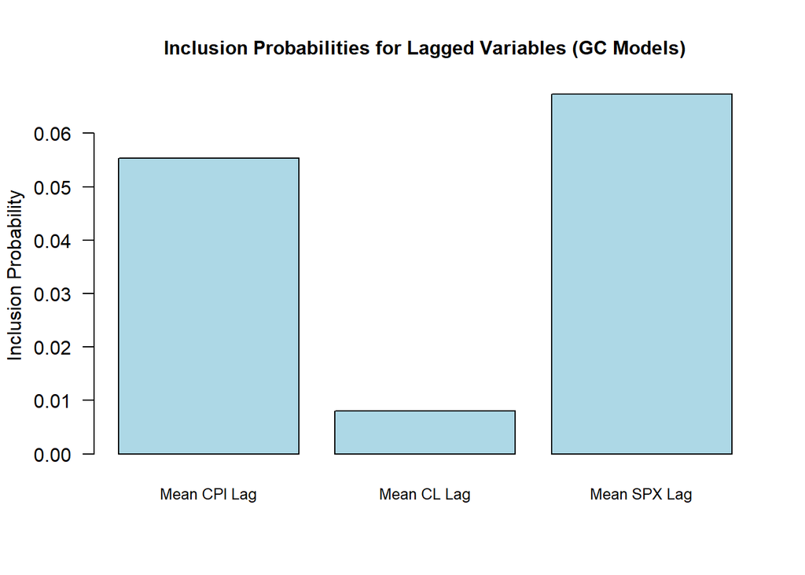

```r
barplot(mean_inclusion_probs,
        names.arg = c("Mean CPI Lag", "Mean CL Lag", "Mean SPX Lag"),
        col = "light blue",
        main = "Inclusion Probabilities for Lagged Variables (GC Models)",
        ylab = "Inclusion Probability",
        las = 1,
        cex.names = 0.8,
        cex.axis = 1,
        cex.main = 1,
        cex.lab = 1)
```

```r
# Plot probs for CL
models_CL = list(dr_CL_1, dr_CL_2, dr_CL_3)
coefficients = c("Mean_CPI_lag_1", "Mean_GC_lag_1", "Mean_SPX_lag_1")
inclusion_probabilities_matrix = matrix(NA, nrow = length(coefficients), ncol = length(models_CL))

for (i in 1:length(coefficients)) {
  for (j in 1:length(models_CL)) {
    inclusion_probabilities_matrix[i, j] = extract_inclusion_probabilities(models_CL[[j]], coefficients[i])
  }
}

mean_inclusion_probs = apply(inclusion_probabilities_matrix, 1, mean)
```

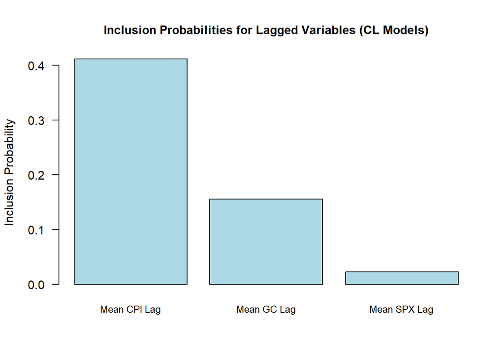

```r
barplot(mean_inclusion_probs,
        names.arg = c("Mean CPI Lag", "Mean GC Lag", "Mean SPX Lag"),
        col = "light blue",
        main = "Inclusion Probabilities for Lagged Variables (CL Models)",
        ylab = "Inclusion Probability",
        las = 1,
        cex.names = 0.8,
        cex.axis = 1,
        cex.main = 1,
        cex.lab = 1)
```

The inclusion probabilities for the lagged predictors in both models are relatively low (less than 0.5), however, the probabilities for the CL model are higher than the GC model. In the GC model, the SPX lag predictor has the highest inclusion probability of the three predictors, meanwhile, in the CL model, the CPI lag predictor has the highest inclusion probability. Since all lag predictors across both models have a probability of being included much less than half of the times, they are relatively not that useful in predicting GC or CL.